# Practical Machine Learning Course Project

Fatih Caglar

2024-09-13

## About the data

- In this project, we analyze the Human Activity Recognition (HAR) Weight Lifting Exercises Dataset and build a classification algorithm to predict the type of activities(`classe` variable) based on sensor data.Six young health participants were asked to perform one set of 10 repetitions of the Unilateral Dumbbell Biceps Curl in five different fashions:
  - exactly according to the specification (**Class A**)
  - throwing the elbows to the front (**Class B**)
  - lifting the dumbbell only halfway (**Class C**)
  - lowering the dumbbell only halfway (**Class D**)
  - throwing the hips to the front (**Class E**)
- The sensors used are accelerometers, gyroscopes and magnetometers placed on arm, forearm, belt and dumbbell.These sensors captures orientation angle (roll - pitch - yaw), acceleration, angular velocity and magnetic field data strengths along x,y and z axes and the statistical features (kurtosis, skewness, max, min, amplitude, variance, standard deviation) of these data are recorded in dataset.

You can find more information about the study here.

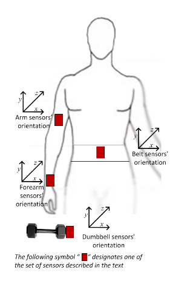

body sensors

## Load the data

```r
training <- read.csv("https://d396qusza40orc.cloudfront.net/predmachlearn/pml-training.csv", na.strings = c("", NA))
testing <- read.csv("https://d396qusza40orc.cloudfront.net/predmachlearn/pml-testing.csv", na.strings = c("", NA))
```

## Load necessary libraries

```r
library(DataExplorer)
library(dplyr)
library(randomForest)
library(caret)
library(ggplot2)
library(gridExtra)
library(reshape2)
library(rpart)
library(rpart.plot)
library(skimr)
library(corrplot)
library(caretEnsemble)
library(pryr)
library(gbm3)
library(glmnet)
```

## Initial looks

```r
introduce(training)
```

```
##    rows columns discrete_columns continuous_columns all_missing_columns
## 1 19622     160               37                123                   0
##   total_missing_values complete_rows total_observations memory_usage
## 1              1921600           406            3139520     22810544
```

```r
dim(testing)
```

```
## [1]  20 160
```

```r
colnames(training)
```

```
##   [1] "X"                        "user_name"
##   [3] "raw_timestamp_part_1"     "raw_timestamp_part_2"
##   [5] "cvtd_timestamp"           "new_window"
##   [7] "num_window"               "roll_belt"
##   [9] "pitch_belt"               "yaw_belt"
##  [11] "total_accel_belt"         "kurtosis_roll_belt"
##  [13] "kurtosis_picth_belt"      "kurtosis_yaw_belt"
##  [15] "skewness_roll_belt"       "skewness_roll_belt.1"
##  [17] "skewness_yaw_belt"        "max_roll_belt"
##  [19] "max_picth_belt"           "max_yaw_belt"
##  [21] "min_roll_belt"            "min_pitch_belt"
##  [23] "min_yaw_belt"             "amplitude_roll_belt"
##  [25] "amplitude_pitch_belt"     "amplitude_yaw_belt"
##  [27] "var_total_accel_belt"     "avg_roll_belt"
##  [29] "stddev_roll_belt"         "var_roll_belt"
```

[output cut: 65 more lines]

```r
#omit metadata
training2 <- training %>% select(-c(X,user_name,raw_timestamp_part_1,raw_timestamp_part_2,cvtd_timestamp,new_window,num_window))
testing2 <- testing %>% select(-c(X,user_name,raw_timestamp_part_1,raw_timestamp_part_2,cvtd_timestamp,new_window,num_window))

#convert outcome into factor
training2$classe <- as.factor(training2$classe)

# Handle missing values: remove columns with more than 70% missing data
na_props <- training2 %>% summarise(across(everything(), ~ sum(is.na(.)) / length(.)))
high_na_cols <- na_props %>% select(where(~ . > 0.7))
training3 <- training2[, !(colnames(training2) %in% colnames(high_na_cols))]
testing3 <- testing2[, !(colnames(testing2) %in% colnames(high_na_cols))]
```

## Splitting the training data into training and validation sets

```r
set.seed(123)
inTrain <- createDataPartition(y = training3$classe, p = 0.7, list = FALSE)
training4 <- training3[inTrain, ]
validation <- training3[-inTrain, ]
testing4 <- testing3
```

## Insights on cleaned training data

```r
# a second look using skim function
skim(training4)
```

Data summary

| Name | training4 |
| --- | --- |
| Number of rows | 13737 |
| Number of columns | 53 |
| _______________________ |  |
| Column type frequency: |  |
| factor | 1 |
| numeric | 52 |
| ________________________ |  |
| Group variables | None |

**Variable type: factor**

| skim_variable | n_missing | complete_rate | ordered | n_unique | top_counts |
| --- | --- | --- | --- | --- | --- |
| classe | 0 | 1 | FALSE | 5 | A: 3906, B: 2658, E: 2525, C: 2396 |

**Variable type: numeric**

| skim_variable | n_missing | complete_rate | mean | sd | p0 | p25 | p50 | p75 | p100 | hist |
| --- | --- | --- | --- | --- | --- | --- | --- | --- | --- | --- |
| roll_belt | 0 | 1 | 64.25 | 62.72 | -28.80 | 1.10 | 113.00 | 123.00 | 162.00 | ▇▁▁▅▅ |
| pitch_belt | 0 | 1 | 0.45 | 22.24 | -55.80 | 1.92 | 5.32 | 15.00 | 60.30 | ▃▁▇▅▁ |
| yaw_belt | 0 | 1 | -11.67 | 94.86 | -180.00 | -88.30 | -13.60 | 11.90 | 179.00 | ▁▇▅▁▃ |
| total_accel_belt | 0 | 1 | 11.29 | 7.75 | 0.00 | 3.00 | 17.00 | 18.00 | 29.00 | ▇▁▂▆▁ |
| gyros_belt_x | 0 | 1 | -0.01 | 0.21 | -1.04 | -0.03 | 0.03 | 0.11 | 2.20 | ▁▇▁▁▁ |
| gyros_belt_y | 0 | 1 | 0.04 | 0.08 | -0.64 | 0.00 | 0.02 | 0.11 | 0.61 | ▁▁▇▃▁ |
| gyros_belt_z | 0 | 1 | -0.13 | 0.24 | -1.46 | -0.20 | -0.10 | -0.02 | 1.61 | ▁▂▇▁▁ |
| accel_belt_x | 0 | 1 | -5.79 | 29.47 | -120.00 | -21.00 | -15.00 | -5.00 | 85.00 | ▁▁▇▁▂ |
| accel_belt_y | 0 | 1 | 30.10 | 28.63 | -69.00 | 3.00 | 33.00 | 61.00 | 164.00 | ▁▇▇▁▁ |
| accel_belt_z | 0 | 1 | -72.38 | 100.40 | -275.00 | -162.00 | -152.00 | 27.00 | 105.00 | ▁▇▁▅▃ |
| magnet_belt_x | 0 | 1 | 55.00 | 63.93 | -52.00 | 8.00 | 34.00 | 58.00 | 485.00 | ▇▁▂▁▁ |
| magnet_belt_y | 0 | 1 | 593.76 | 35.35 | 354.00 | 581.00 | 601.00 | 610.00 | 673.00 | ▁▁▁▇▃ |
| magnet_belt_z | 0 | 1 | -345.41 | 64.17 | -621.00 | -375.00 | -319.00 | -306.00 | 287.00 | ▁▇▁▁▁ |
| roll_arm | 0 | 1 | 17.78 | 73.20 | -178.00 | -32.20 | 0.00 | 77.50 | 180.00 | ▁▃▇▆▂ |
| pitch_arm | 0 | 1 | -4.46 | 30.72 | -88.20 | -26.00 | 0.00 | 11.50 | 88.50 | ▁▅▇▂▁ |
| yaw_arm | 0 | 1 | -0.52 | 71.61 | -180.00 | -43.10 | 0.00 | 46.70 | 180.00 | ▁▃▇▃▂ |
| total_accel_arm | 0 | 1 | 25.53 | 10.45 | 1.00 | 17.00 | 27.00 | 33.00 | 65.00 | ▃▆▇▁▁ |
| gyros_arm_x | 0 | 1 | 0.02 | 2.00 | -6.37 | -1.36 | 0.06 | 1.53 | 4.87 | ▁▃▇▆▂ |
| gyros_arm_y | 0 | 1 | -0.25 | 0.86 | -3.44 | -0.79 | -0.24 | 0.16 | 2.81 | ▁▂▇▂▁ |
| gyros_arm_z | 0 | 1 | 0.27 | 0.55 | -2.33 | -0.08 | 0.23 | 0.72 | 2.66 | ▁▂▇▃▁ |
| accel_arm_x | 0 | 1 | -60.05 | 182.68 | -404.00 | -241.00 | -46.00 | 84.00 | 435.00 | ▇▆▇▅▁ |
| accel_arm_y | 0 | 1 | 32.61 | 109.66 | -318.00 | -54.00 | 14.00 | 139.00 | 308.00 | ▁▃▇▇▂ |
| accel_arm_z | 0 | 1 | -70.84 | 133.98 | -630.00 | -142.00 | -48.00 | 23.00 | 292.00 | ▁▁▅▇▁ |
| magnet_arm_x | 0 | 1 | 192.20 | 444.52 | -584.00 | -301.00 | 290.00 | 640.00 | 782.00 | ▆▃▂▃▇ |
| magnet_arm_y | 0 | 1 | 155.96 | 201.65 | -392.00 | -8.00 | 200.00 | 322.00 | 583.00 | ▁▃▅▇▂ |
| magnet_arm_z | 0 | 1 | 307.10 | 325.84 | -597.00 | 129.00 | 445.00 | 546.00 | 694.00 | ▁▂▂▃▇ |
| roll_dumbbell | 0 | 1 | 23.56 | 70.25 | -153.71 | -19.94 | 48.07 | 67.78 | 153.55 | ▂▂▃▇▂ |
| pitch_dumbbell | 0 | 1 | -10.84 | 37.03 | -149.59 | -40.96 | -20.85 | 17.35 | 149.40 | ▁▆▇▂▁ |
| yaw_dumbbell | 0 | 1 | 2.07 | 82.36 | -150.87 | -77.57 | 0.00 | 79.97 | 154.95 | ▃▇▅▅▆ |
| total_accel_dumbbell | 0 | 1 | 13.65 | 10.24 | 0.00 | 4.00 | 10.00 | 19.00 | 58.00 | ▇▅▃▁▁ |
| gyros_dumbbell_x | 0 | 1 | 0.15 | 1.78 | -204.00 | -0.03 | 0.13 | 0.35 | 2.20 | ▁▁▁▁▇ |
| gyros_dumbbell_y | 0 | 1 | 0.05 | 0.66 | -2.10 | -0.14 | 0.03 | 0.21 | 52.00 | ▇▁▁▁▁ |
| gyros_dumbbell_z | 0 | 1 | -0.12 | 2.72 | -2.38 | -0.31 | -0.13 | 0.03 | 317.00 | ▇▁▁▁▁ |
| accel_dumbbell_x | 0 | 1 | -28.43 | 67.35 | -419.00 | -50.00 | -8.00 | 10.00 | 235.00 | ▁▁▆▇▁ |
| accel_dumbbell_y | 0 | 1 | 51.96 | 80.82 | -189.00 | -9.00 | 40.00 | 110.00 | 315.00 | ▁▇▇▅▁ |
| accel_dumbbell_z | 0 | 1 | -37.52 | 109.28 | -273.00 | -141.00 | 0.00 | 38.00 | 318.00 | ▃▃▇▂▁ |
| magnet_dumbbell_x | 0 | 1 | -328.71 | 340.26 | -643.00 | -535.00 | -480.00 | -307.00 | 584.00 | ▇▂▁▁▂ |
| magnet_dumbbell_y | 0 | 1 | 219.91 | 328.00 | -3600.00 | 231.00 | 310.00 | 390.00 | 633.00 | ▁▁▁▁▇ |
| magnet_dumbbell_z | 0 | 1 | 45.00 | 139.39 | -262.00 | -46.00 | 12.00 | 95.00 | 452.00 | ▁▇▆▂▂ |
| roll_forearm | 0 | 1 | 33.19 | 108.26 | -180.00 | -2.44 | 20.60 | 140.00 | 180.00 | ▃▂▇▂▇ |
| pitch_forearm | 0 | 1 | 10.77 | 28.42 | -72.50 | 0.00 | 9.60 | 28.90 | 89.80 | ▁▁▇▃▁ |
| yaw_forearm | 0 | 1 | 19.03 | 103.90 | -180.00 | -70.50 | 0.00 | 111.00 | 180.00 | ▅▅▇▆▇ |
| total_accel_forearm | 0 | 1 | 34.72 | 10.08 | 0.00 | 29.00 | 36.00 | 41.00 | 108.00 | ▁▇▂▁▁ |
| gyros_forearm_x | 0 | 1 | 0.16 | 0.66 | -22.00 | -0.22 | 0.05 | 0.56 | 3.52 | ▁▁▁▁▇ |
| gyros_forearm_y | 0 | 1 | 0.09 | 3.43 | -7.02 | -1.46 | 0.03 | 1.64 | 311.00 | ▇▁▁▁▁ |
| gyros_forearm_z | 0 | 1 | 0.16 | 2.06 | -5.55 | -0.18 | 0.08 | 0.49 | 231.00 | ▇▁▁▁▁ |
| accel_forearm_x | 0 | 1 | -62.46 | 180.51 | -496.00 | -179.00 | -57.00 | 75.00 | 477.00 | ▂▆▇▅▁ |
| accel_forearm_y | 0 | 1 | 163.12 | 200.28 | -595.00 | 55.00 | 201.00 | 312.00 | 923.00 | ▁▃▇▃▁ |
| accel_forearm_z | 0 | 1 | -56.51 | 138.45 | -446.00 | -182.00 | -41.00 | 26.00 | 287.00 | ▁▇▅▅▃ |
| magnet_forearm_x | 0 | 1 | -314.03 | 346.44 | -1280.00 | -617.00 | -381.00 | -77.00 | 672.00 | ▁▇▆▅▁ |
| magnet_forearm_y | 0 | 1 | 377.48 | 507.68 | -892.00 | 4.00 | 586.00 | 735.00 | 1480.00 | ▂▂▂▇▁ |
| magnet_forearm_z | 0 | 1 | 391.60 | 368.89 | -966.00 | 186.00 | 509.00 | 651.00 | 1070.00 | ▁▁▃▇▃ |

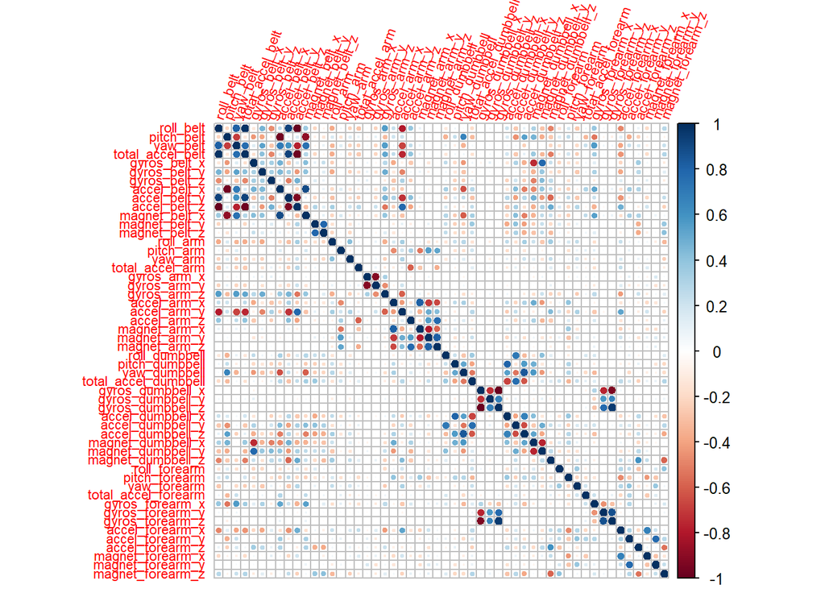

```r
#check correlations
numeric_features <- training4 %>% select_if(is.numeric)
cor_matrix <- cor(numeric_features)
corrplot(cor_matrix,
         tl.cex = .7,     # Reduce text label size
         tl.srt = 70,      # Rotate the labels by 45 degrees
         method = "circle" # Use circles for a clean look
)
```

```r
#check class imbalance
table(training4$classe)
```

```
##
##    A    B    C    D    E
## 3906 2658 2396 2252 2525
```

- There are skewed variables in our data, although not many.
- The scales of some sensor measurement data are different where some of them high standard deviations.
- There is some collinearity in our data, especially between measurements from same device or same body parts.
- There is no class imbalance in outcome.
- Based on this insights, we will center and scale our data and reduce it to principal components.

## Preprocess the data

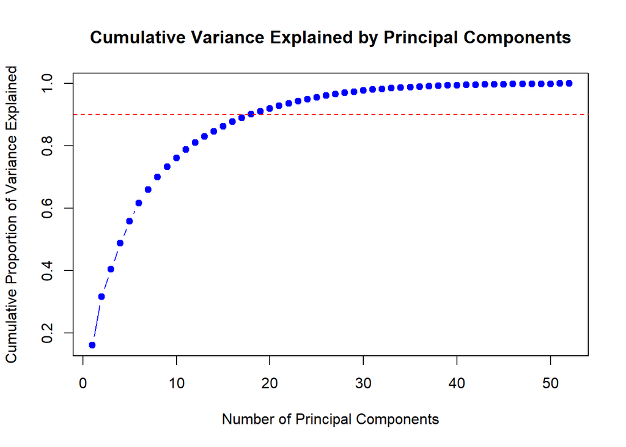

```r
#center and scale training4
preProc_train <- preProcess(training4, method = c("center", "scale"))

#transform the data
training5 <- predict(preProc_train, newdata = training4)
validation2 <- predict(preProc_train, newdata = validation)
testing5 <- predict(preProc_train, newdata = testing4)

#apply pca
pca <- prcomp(training5[, -which(names(training5) %in% c("classe"))])
pca_var <- pca$sdev^2 / sum(pca$sdev^2)
cum_var <- cumsum(pca_var)

#cumulative explained variance vs. number of principal components
plot(cum_var, xlab = "Number of Principal Components",
     ylab = "Cumulative Proportion of Variance Explained",
     type = "b", col = "blue", pch = 19,
     main = "Cumulative Variance Explained by Principal Components")
abline(h = 0.9, col = "red", lty = 2)
```

```r
pca_transformed_data <- pca$x[, 1:18]

#transform the data using principal components by 90% cutoff on explained variance
training6 <- data.frame(pca_transformed_data, classe = training5$classe)
validation3 <- data.frame(predict(pca, newdata = validation2)[, 1:18],classe = validation2$classe)
testing6 <- predict(pca, newdata = testing5)[, 1:18]
```

## Model Selection

- We will define a trainControl function `control_base` because we will plan to stack models in the end.
- First we train a multinomial logistic regression model.

### Multinomial Logistic Regression

```r
control_base <- trainControl(method = "cv", number = 5, savePredictions = "final", classProbs = TRUE)
Rprof("memory_profile.out", memory.profiling = TRUE)
model_glm <- train(classe ~ .,
                   data = training6,
                   method = "multinom",
                   trControl = control_base,
                   verbose = FALSE)
Rprof(NULL)
```

```r
time_glm1 <- summaryRprof("memory_profile.out", memory = "both")$by.total
memory_glm1 <- summaryRprof("memory_profile.out", memory = "both")$memory
tm_glm <- sapply(list(time_glm1$total.time,time_glm1$mem.total),max)
model_glm_preds <- predict(model_glm,validation3)
conf_matrix <- confusionMatrix(model_glm_preds, validation3$classe)
model_glm$results
```

```
##   decay  Accuracy     Kappa  AccuracySD    KappaSD
## 1 0e+00 0.5145256 0.3815310 0.008621836 0.01095427
## 2 1e-04 0.5145256 0.3815310 0.008621836 0.01095427
## 3 1e-01 0.5145256 0.3815327 0.008621836 0.01095683
```

```r
conf_matrix$overall["Accuracy"]
```

```
##  Accuracy
## 0.4968564
```

#### Tuning `model_glm`

```r
tune_grid <- expand.grid(decay = seq(0, 0.1, by = 0.01))

Rprof("memory_profile.out", memory.profiling = TRUE)
model_glm_tuned <- train(
    classe ~ .,
    data = training6,
    method = "multinom",
    trControl = control_base,
    tuneGrid = tune_grid,
    maxit = 200,
    verbose = FALSE
)
Rprof(NULL)
time_glm_tuned <- summaryRprof("memory_profile.out", memory = "both")$by.total
```

```r
tm_glm_tuned <- sapply(list(time_glm_tuned$total.time,time_glm_tuned$mem.total),max)
head(model_glm_tuned$results)
```

```
##   decay  Accuracy     Kappa AccuracySD    KappaSD
## 1  0.00 0.5146675 0.3817817 0.01229979 0.01566126
## 2  0.01 0.5147403 0.3818760 0.01229335 0.01565946
## 3  0.02 0.5147403 0.3818760 0.01229335 0.01565946
## 4  0.03 0.5146675 0.3817817 0.01229979 0.01566126
## 5  0.04 0.5147403 0.3818760 0.01229335 0.01565946
## 6  0.05 0.5146675 0.3817817 0.01229979 0.01566126
```

```r
model_glm_tuned_preds <- predict(model_glm_tuned,validation3)
conf_matrix <- confusionMatrix(model_glm_tuned_preds, validation3$classe)
conf_matrix$overall["Accuracy"]
```

```
##  Accuracy
## 0.4968564
```

### KNN

- We train k-nearest-neighbors model using `control_base` again and 10 different numbers of $k$.

```r
Rprof("memory_profile.out", memory.profiling = TRUE)
model_knn <- train(classe ~ ., data = training6, method = "knn", trControl = control_base, tuneLength = 10)
Rprof(NULL)
time_knn <- summaryRprof("memory_profile.out", memory = "both")$by.total
tm_knn <- sapply(list(time_knn$total.time,time_knn$mem.total),max)
head(model_knn$results)
```

```
##    k  Accuracy     Kappa  AccuracySD     KappaSD
## 1  5 0.9406720 0.9249422 0.005791014 0.007312515
## 2  7 0.9240012 0.9038475 0.005780462 0.007307526
## 3  9 0.9109709 0.8873732 0.007378862 0.009360324
## 4 11 0.8986685 0.8717871 0.005768835 0.007342700
## 5 13 0.8881855 0.8585090 0.004984859 0.006333097
## 6 15 0.8764658 0.8436722 0.004374847 0.005573689
```

```r
model_knn_preds <- predict(model_knn,validation3)
conf_matrix <- confusionMatrix(model_knn_preds, validation3$classe)
conf_matrix$overall["Accuracy"]
```

```
##  Accuracy
## 0.9502124
```

- Knn performed better than glm but we will try decision trees for a much better accuracy.

### Decision Tree

```r
tree_tune_grid <- expand.grid(cp = seq(0.001, 0.05, by = 0.001))
Rprof("memory_profile.out", memory.profiling = TRUE)
model_tree <- train(classe ~ ., data = training6,
                    method = "rpart",
                    trControl = control_base,
                    tuneGrid = tree_tune_grid)
Rprof(NULL)
time_tree <- summaryRprof("memory_profile.out", memory = "both")$by.total
tm_tree <- sapply(list(time_tree$total.time,time_tree$mem.total),max)
model_tree_preds <- predict(model_tree,validation3)
conf_matrix <- confusionMatrix(model_tree_preds, validation3$classe)
conf_matrix$overall["Accuracy"]
```

```
##  Accuracy
## 0.7231946
```

### Random Forest

```r
Rprof("memory_profile.out", memory.profiling = TRUE)
model_rf <- train(classe ~ ., data = training6, method = "rf",trControl = control_base, importance = TRUE)
Rprof(NULL)
time_rf <- summaryRprof("memory_profile.out", memory = "both")$by.total
tm_rf <- sapply(list(time_rf$total.time,time_rf$mem.total),max)
model_rf_preds <- predict(model_rf$finalModel,validation3)
conf_matrix <- confusionMatrix(model_rf_preds, validation3$classe)
conf_matrix$overall["Accuracy"]
```

```
##  Accuracy
## 0.9712829
```

- Random Forest performs well on training data. We will try Boosting to see if it can increase accuracy.

### Boosting

```r
Rprof("memory_profile.out", memory.profiling = TRUE)
model_boost <- train(
  classe ~ .,
  method = "gbm",
  data = training6,
  trControl = control_base,
  verbose = FALSE,  # Prevents printing during training
  tuneLength = 10   # This will try 10 different hyperparameter combinations
)
Rprof(NULL)
```

```r
time_boost <- summaryRprof("memory_profile.out", memory = "both")$by.total
tm_boost <- sapply(list(time_boost$total.time,time_boost$mem.total),max)
model_boost_preds <- predict(model_boost,validation3)
conf_matrix <- confusionMatrix(model_boost_preds, validation3$classe)
conf_matrix$overall["Accuracy"]
```

```
##  Accuracy
## 0.9604078
```

### Model Stacking

```r
# Model Stacking with Profiling
base_learners <- list(
    rpart = model_tree,    # Using the caret model directly
    rf = model_rf,         # Full caret model
    knn = model_knn,       # Full caret model
    glm = model_glm_tuned, # Logistic regression tuned model
    gbm = model_boost      # Boosted model
)

# Control for stacking models
stack_control <- trainControl(method = "cv", number = 5, savePredictions = "final", classProbs = TRUE)

# Profiling the stacking process
Rprof("memory_profile_stack.out", memory.profiling = TRUE)

# Stacking the models
model_stack <- caretStack(
    base_learners,
    method = "glmnet",    # Use glmnet for model stacking
    metric = "Accuracy",  # Metric to optimize
    trControl = stack_control
)

Rprof(NULL)
```

```r
# Profiling results
time_stack <- summaryRprof("memory_profile_stack.out", memory = "both")$by.total
tm_stack <- sapply(list(time_stack$total.time, time_stack$mem.total), max)

summary(model_stack)
```

```
## The following models were ensembled: rpart, rf, knn, glm, gbm
##
## Model Importance:
## rpart_B rpart_C rpart_D rpart_E    rf_B    rf_C    rf_D    rf_E   knn_B   knn_C
##  0.0055  0.0031  0.0033  0.0008  0.2975  0.1697  0.1926  0.1654  0.0063  0.0176
##   knn_D   knn_E   glm_B   glm_C   glm_D   glm_E   gbm_B   gbm_C   gbm_D   gbm_E
##  0.0253  0.0298  0.0065  0.0017  0.0019  0.0029  0.0136  0.0340  0.0122  0.0104
##
## Model accuracy:
##    model_name   metric     value          sd
##        <char>   <char>     <num>       <num>
## 1:   ensemble Accuracy 0.9708828 0.003681060
## 2:      rpart Accuracy 0.7328383 0.003144346
## 3:         rf Accuracy 0.9657134 0.004275948
## 4:        knn Accuracy 0.9406720 0.005791014
## 5:   multinom Accuracy 0.5147403 0.012293350
## 6:        gbm Accuracy 0.9501347 0.002287768
```

```r
model_stack_preds <- predict(model_stack, newdata = validation3)
model_stack_preds <- apply(model_stack_preds, 1, function(x) colnames(model_stack_preds)[which.max(x)])
model_stack_preds <- as.factor(model_stack_preds)
validation_actual <- as.factor(validation3$classe)
conf_matrix <- confusionMatrix(model_stack_preds, validation_actual)
conf_matrix$overall["Accuracy"]
```

```
##  Accuracy
## 0.9785896
```

### Comparing the Models

```r
models <- list(
    glm = model_glm,
    glm_tuned = model_glm_tuned,
    knn = model_knn,
    tree = model_tree,
    rf = model_rf,
    boost = model_boost,
    stack = model_stack
)

# Initialize a list to store predictions
predictions <- list()

# Generate predictions for each model
for (model_name in names(models)) {
    if (model_name == "stack") {
        # For the stacked model, predictions may be probabilities
        pred_probs <- predict(models[[model_name]], newdata = validation3)
        # Convert probabilities to class labels
        preds <- apply(pred_probs, 1, function(x) colnames(pred_probs)[which.max(x)])
        predictions[[model_name]] <- as.factor(preds)
    } else {
        # For other models, directly predict class labels
        predictions[[model_name]] <- predict(models[[model_name]], newdata = validation3)
    }
}



# Initialize a data frame to store performance metrics
performance_metrics <- data.frame(
    Model = character(),
    Class = character(),
    Sensitivity = numeric(),
    Specificity = numeric(),
    Pos_Pred_Value = numeric(),
    Neg_Pred_Value = numeric(),
    Prevalence = numeric(),
    Detection_Rate = numeric(),
    Detection_Prevalence = numeric(),
    Balanced_Accuracy = numeric(),
    stringsAsFactors = FALSE
)

# Loop over each model to extract per-class metrics
for (model_name in names(predictions)) {
    cm <- confusionMatrix(predictions[[model_name]], validation3$classe)

    # Extract the per-class metrics
    byClass <- as.data.frame(cm$byClass)

    # Since in multiclass, the row names might be like "Class: A", extract the class labels
    byClass$Class <- rownames(byClass)
    byClass$Class <- sub("Class: ", "", byClass$Class)

    # Add the model name
    byClass$Model <- model_name

    # Reorder columns
    byClass <- byClass[, c("Model", "Class", names(byClass)[1:(ncol(byClass)-2)])]

    # Append to the performance_metrics data frame
    performance_metrics <- rbind(performance_metrics, byClass)
}

# Rename columns for clarity
colnames(performance_metrics) <- c(
    "Model", "Class", "Sensitivity", "Specificity",
    "Pos_Pred_Value", "Neg_Pred_Value", "Precision",
    "Recall", "F1", "Prevalence", "Detection_Rate",
    "Detection_Prevalence", "Balanced_Accuracy"
)

performance_metrics <- performance_metrics %>% select(-Recall) %>% arrange(desc(Balanced_Accuracy))

profiling_data <- data.frame(
  Model = c("glm", "glm_tuned", "knn", "tree", "rf", "boost", "stack"),
  Training_Time = c(tm_glm[1], tm_glm_tuned[1], tm_knn[1],
                    tm_tree[1], tm_rf[1], tm_boost[1], tm_stack[1]),
  Memory_Usage = c(tm_glm[2], tm_glm_tuned[2], tm_knn[2],
                    tm_tree[2], tm_rf[2], tm_boost[2], tm_stack[2])
)
profiling_data <- profiling_data %>% arrange(desc(Memory_Usage),desc(Training_Time)) %>% mutate(Training_Time = round(Training_Time/60,3))
rownames(performance_metrics) <- 1:35
head(performance_metrics,10)
```

```
##    Model Class Sensitivity Specificity Pos_Pred_Value Neg_Pred_Value Precision
## 1  stack     E   0.9889094   0.9977098      0.9898242      0.9975021 0.9898242
## 2  stack     A   0.9916368   0.9938257      0.9845789      0.9966659 0.9845789
## 3     rf     A   0.9898447   0.9919259      0.9798936      0.9959466 0.9798936
## 4  boost     A   0.9880526   0.9905011      0.9763872      0.9952279 0.9763872
## 5     rf     E   0.9759704   0.9983344      0.9924812      0.9946069 0.9924812
## 6    knn     A   0.9826762   0.9871764      0.9682166      0.9930721 0.9682166
## 7  stack     B   0.9727831   0.9949431      0.9787986      0.9934778 0.9787986
## 8  stack     C   0.9707602   0.9892982      0.9503817      0.9937978 0.9503817
## 9  boost     E   0.9611830   0.9966687      0.9848485      0.9913025 0.9848485
## 10 stack     D   0.9595436   0.9973583      0.9861407      0.9921164 0.9861407
##           F1 Prevalence Detection_Rate Detection_Prevalence Balanced_Accuracy
## 1  0.9893666  0.1838573      0.1818182            0.1836873         0.9933096
## 2  0.9880952  0.2844520      0.2820731            0.2864911         0.9927312
## 3  0.9848440  0.2844520      0.2815633            0.2873407         0.9908853
## 4  0.9821853  0.2844520      0.2810535            0.2878505         0.9892768
## 5  0.9841566  0.1838573      0.1794393            0.1807986         0.9871524
## 6  0.9753928  0.2844520      0.2795242            0.2887001         0.9849263
## 7  0.9757816  0.1935429      0.1882753            0.1923534         0.9838631
## 8  0.9604629  0.1743415      0.1692438            0.1780799         0.9800292
## 9  0.9728718  0.1838573      0.1767205            0.1794393         0.9789259
## 10 0.9726604  0.1638063      0.1571793            0.1593883         0.9784509
```

- As seen in the comparison table, stacking model outperforms other models and we choose it for predictions and evaluation on unseen data.

```r
profiling_data
```

```
##       Model Training_Time Memory_Usage
## 1        rf         6.001      17746.9
## 2     boost        38.109      16900.4
## 3      tree         0.137       4141.1
## 4     stack         0.721       3347.8
## 5       knn         1.052       2349.2
## 6 glm_tuned         1.935       2207.5
## 7       glm         0.631        758.3
```

- Random Forest and Boosting from stacked models have highes computation time and use largest memory.